# COMP8220 - MAJOR PROJECT - Living Species Image Classification

## Name : Phan Vinh Phu

## ID : 45747989

## Outline

### 1. Introduction

### 2. Data Preprocessing

### 3. Conventional ML Model

### 4. Deep Learning Model

#### EfficientNetV2S

#### MobileNetV2

### 5. Discussion

# 1. Introduction

In recent years, image classification has become an increasingly important task in the field of computer vision. The ability to automatically classify images has a wide range of applications, from recognizing objects in photographs to identifying medical conditions in diagnostic images.

In this project, I will be working with a dataset of living things, which includes images of animals and plants. The dataset contains a set of coarse-grained labels, consisting of 8 different categories and another set of fine-grained which consists of 50 labels.

The coarse-grained labels come from the Class rank) in the widely used Linnaean biological taxonomy; the 8 labels we are using are 'Aves', 'Reptilia', 'Mammalia', 'Arachnida', 'Magnoliopsida', 'Insecta', 'Liliopsida', 'Pinopsida'.

The fine-grained labels come from the Family rank). One example of a fine-grained label is Family Scolopacidae representing [sandpipers](https://en.wikipedia.org/wiki/Sandpiper) (wading bird). Scolopacidae are part of Class Aves (broadly, [birds](https://en.wikipedia.org/wiki/Bird)).

I carried out this report for only "Coarse" task since the dataset is same for "Coarse" and "Fine".The only different thing is the labels. My goal is to develop a machine learning model that can accurately classify images in this dataset based on their category label. I will explore different machine learning algorithms and techniques, such as convolutional neural networks (CNNs), Random Forest, Supported Vector Machine,....

In this notebook, only necessary chunks of code have been retained to explain the implementation. The rest of the code is deducted to keep the report simple.

# 2. Data Preprocessing

The problem framing and data collection were defined from the Description of the MajorProject. Also, I used the code from the code_stub.ipynb file to read the data. Before modeling, I have encountered some problems of dataset. Therefore, it is necessary to do some changes.

Thus, I decided to move all images from validation folder into train folder and merge the val.csv to train.csv. After that, I use ImageDataGenerator of tensorflow library to reallocate the data 80% for train set and 20% for validataion set.

**Unbalanced Design Data** : Regard of Coarse data, the design of dataset is unbalanced.While it has a large amount of **Magnoliopsida, Insecta, Aves** images, there are very few images of **Reptilia, Pinopsida, Arachnida, Mammalia, Liliopsida**. Due to lack of images for some classes, the prediction is poor when predicting these classes in the test dataset.

To tackle this issue, instead of using accuracy alone, F1 score provide a more comprehensive understanding of the model's performance across different classes. Beside that, **resampling** and **data augmentation** are efficient techniques to create more images for Reptilia, Pinopsida, Arachnida, Mammalia class. In this case, I rotate the original images to create new images for oversampling the minority class. In this way, I can create a more balanced dataset and provide the model with more examples to learn from. In addition, moving images from validation set to train set and reallocating images help to increase the number of Reptilia, Pinopsida, Arachnida, Mammalia images.(The code is shown below)

**Label Encoding** : The labels in csv files give the information of image. They are in form of numerical variable which is from 0 to 7. There are several drawbacks when using this scale of labels such as creating bias in the model or ordinality assumptions. Therefore, labels are encoded into the vector of 0 and 1 (onehot encoding). When ImageDataGenerator is used to load data, it will automatically encode the labels.

### Import libraries

```python
import numpy as np
import pandas as pd
import os
import json
import shutil
import random
import matplotlib.pyplot as plt
import pathlib
import tensorflow as tf
from pathlib import Path
from sklearn.ensemble import RandomForestClassifier
```

### Mount drive

```python
from google.colab import drive
drive.mount('/content/drive')
```

### Unzip data file

```python
# Your file will probably be called this, if you used the regular Kaggle download.
!unzip -q /content/drive/MyDrive/ImageClassification/living-thing-classification-coarse.zip
```

### Move all images from "val" folder to "train" folder

The code provided moves all the images from the validation folder (val_folder) to the train folder (train_folder) and then deletes the validation folder. This effectively combines the validation set with the training set.

```python
# Define the paths to the train and val folders
train_folder = '/content/public/train'
val_folder = '/content/public/val'

# Move images from val folder to train folder
for filename in os.listdir(val_folder):
    src_path = os.path.join(val_folder, filename)
    dst_path = os.path.join(train_folder, filename)
    shutil.move(src_path, dst_path)

# Delete the val folder
shutil.rmtree(val_folder)
```

### Move all rows from val.csv to train.csv

The code provided merges the contents of the val.csv file into the train.csv file, and then deletes the val.csv file.

```python
train_csv = "/content/public/train.csv"
val_csv = "/content/public/val.csv"

# Read the train.csv and val.csv files
train_data = pd.read_csv(train_csv)
val_data = pd.read_csv(val_csv)

# Merge val.csv into train.csv
merged_data = pd.concat([train_data, val_data[1:]])

# Write the merged data back to train.csv
merged_data.to_csv(train_csv, index=False)

# Delete val.csv
os.remove(val_csv)
```

### Move images to subfolder follow the labels in csv file

The code is for creating subfolders within the data folder and moving images into their respective class folders based on the label information. It also renames the subfolders according to the label information.

```python
ROOT_PATH = Path('/content/public')
info_file = '/content/public/info.json'

def create_data_folders(fine):
    if fine:
        data = 'fine'
        num_classes = 50
        column_name = 'fine'
    else:
        data = 'coarse'
        num_classes = 8
        column_name = 'coarse'

    df = pd.read_csv(train_csv)

    # Create subfolders within the data folder
    for label in range(num_classes):
        subfolder = os.path.join(train_folder, str(label))
        os.makedirs(subfolder, exist_ok=True)

    # Load the label information from the info.json file
    with open(info_file) as f:
        label_info = json.load(f)

    # Move images to respective data class folders
    for index, row in df.iterrows():
        image_name = row['filename']
        data_label = row[column_name]

        src_path = os.path.join(ROOT_PATH, 'train', image_name)
        dst_path = os.path.join(ROOT_PATH, 'train', str(data_label), image_name)

        if os.path.exists(src_path):
            shutil.move(src_path, dst_path)

    print(f"Move {data} data successfully")

    # Rename subfolders in the data folder based on label_info
    for i in range(num_classes):
        old_folder = os.path.join(train_folder, str(i))
        new_folder = os.path.join(train_folder, label_info[data][i])
        os.rename(old_folder, new_folder)

    print(f"Rename {data} subfolders successfully")

# Usage example:
create_data_folders(fine=False)  # Create "coarse" data subfolders and move images
# create_data_folders(fine=True)  # Create "fine" data subfolders and move images
```

```
Move coarse data successfully
Rename coarse subfolders successfully
```

### The distribution of dataset

Show the distribution of dataset

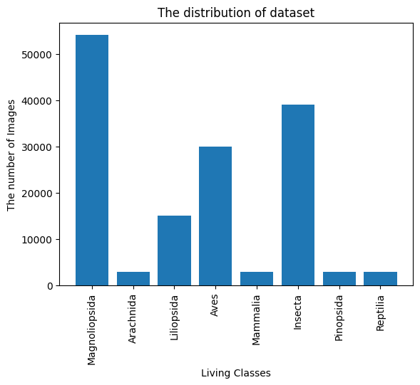

```python
# Get the lengths of each subfolder
folder_lengths = [len(os.listdir(os.path.join(train_folder, folder))) for folder in folders]

# Plot the bar plot
plt.bar(folders, folder_lengths)
plt.xlabel('Living Classes')
plt.ylabel('The number of Images')
plt.title('The distribution of dataset')
plt.xticks(rotation=90)
plt.show()
```

### Data augmentation to balance the data

Resampling and data augmentation are applied to address the unbalanced design issue. The code will loop through each subfolder in the train_folder directory and perform image rotation to create new rotated images. The number of new images created depends on the folder.

```python
from PIL import Image

# Define the parent folder
train_folder = '/content/public/train'

# Define the four subfolders
folders = ['Arachnida', 'Mammalia', 'Pinopsida', 'Reptilia', 'Liliopsida']

# Loop through each subfolder
for folder in folders:
    # Construct the full path to the subfolder
    folder_path = os.path.join(train_folder, folder)

    # Get the list of image files in the subfolder
    image_files = os.listdir(folder_path)

    # Determine the number of new images based on the folder
    if folder == "Liliopsida":
        num_new_images = 2
    else:
        num_new_images = 10

    # Loop through each image file
    for image_file in image_files:
        # Construct the full path to the image
        image_path = os.path.join(folder_path, image_file)

        # Open the original image
        original_image = Image.open(image_path)

        # Rotate the original image and create new rotated images
        for i in range(1, num_new_images + 1):
            # Calculate the rotation angle for each new image
            rotation_angle = i * (360 / num_new_images)

            # Rotate the original image by the calculated angle
            rotated_image = original_image.rotate(rotation_angle)

            # Save the rotated image to the same subfolder
            rotated_image.save(os.path.join(folder_path, f"rotated_{i}_{image_file}"))
```

### After creating more images, the distribition of dataset has been improved

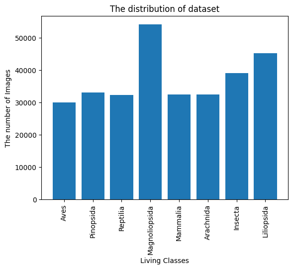

```python
# Get a list of subfolders in the train folder
folders = [folder for folder in os.listdir(train_folder) if os.path.isdir(os.path.join(train_folder, folder))]
# Get the lengths of each subfolder
folder_lengths = [len(os.listdir(os.path.join(train_folder, folder))) for folder in folders]


# Plot the bar plot
plt.bar(folders, folder_lengths)
plt.xlabel('Living Classes')
plt.ylabel('The number of Images')
plt.title('The distribution of dataset')
plt.xticks(rotation=90)
plt.show()
```

### Create a dataset

Using an ImageDataGenerator instance for creating training and validation data. The ImageDataGenerator is a powerful tool in TensorFlow that allows for data augmentation and preprocessing during training

```python
# Define some parameters
train_folder = '/content/public/train'
data_dir = pathlib.Path(train_folder)

batch_size = 32
image_size = (224, 224)

# Create an instance of ImageDataGenerator for train and val data
train_datagen = tf.keras.preprocessing.image.ImageDataGenerator(rescale = 1./127.5,
                            horizontal_flip = True,
                            vertical_flip = True,
                            validation_split = 0.2)
```

It's good practice to use a validation split when developing your model. Use 80% of the images for training and 20% for validation.

```python
train_ds = train_datagen.flow_from_directory(
  data_dir,
  target_size = image_size,
  batch_size = batch_size,
  class_mode = 'categorical',
  subset = 'training',
  color_mode="rgb",)
```

```
Found 120001 images belonging to 8 classes.
```

```python
val_ds = train_datagen.flow_from_directory(
  data_dir,
  target_size = image_size,
  batch_size = batch_size,
  class_mode = 'categorical',
  subset = 'validation',
  color_mode="rgb",)
```

```
Found 29998 images belonging to 8 classes.
```

You can find the class names in the class_names attribute on these datasets. These correspond to the directory names in alphabetical order.

```python
class_names = train_ds.class_indices

num_classes = len(class_names)
print(class_names)
print(num_classes)
```

```
{'Arachnida': 0, 'Aves': 1, 'Insecta': 2, 'Liliopsida': 3, 'Magnoliopsida': 4, 'Mammalia': 5, 'Pinopsida': 6, 'Reptilia': 7}
8
```

### Visualize the data

Here are the first nine images from the training dataset:

[output not shown]

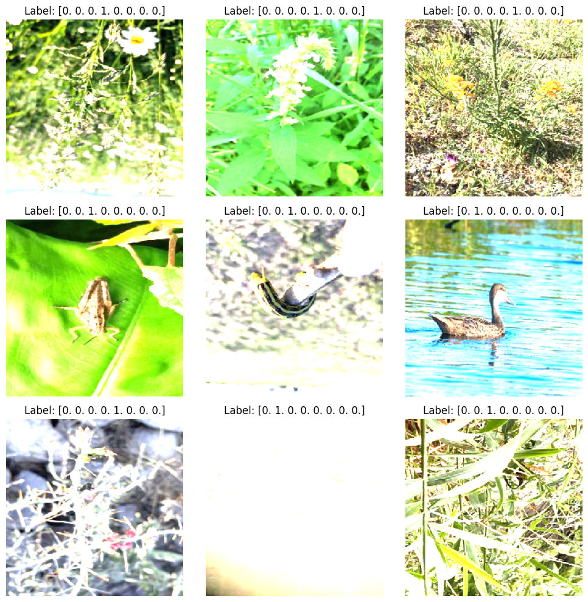

```python
# Get the first nine images and labels from the training dataset
images, labels = next(iter(train_ds))
images = images[:9]
labels = labels[:9]

# Create a grid of subplots
fig, axes = plt.subplots(3, 3, figsize=(10, 10))
axes = axes.flatten()

# Plot each image with its label
for i in range(len(images)):
    axes[i].imshow(images[i])
    axes[i].set_title(f"Label: {labels[i]}")
    axes[i].axis('off')

plt.tight_layout()
plt.show()
```

# 2. Conventional ML Model

The task is **image classification** for color images, so this is **supervised, categorical (classifcation), batch problem**. Therefore, the machine learning classifiers which can be use in this case are Logistic Regression, Decision Trees, Random Forest, Support Vector Machines (SVM) , K-Nearest Neighbors (KNN). In this project, I decide to use **Support Vector Machines (SVM)** and **Random Forest** for the task.

The reason for my choice is that **Support Vector Machines (SVM)** perform well in high-dimensional spaces, which is suitable for image classification where each pixel can be considered a feature. Beside that, **Random Forest** is an ensemble learning method that combines multiple decision trees. This enables it to capture complex interactions and relationships between features in the image data. Random Forest helps to reduce overfitting by aggregating predictions from multiple decision trees, preventing the model from memorizing noise or irrelevant patterns in the training data.

Before trainning, I splitted the dataset into 80% for train set and 20% for validation set as I mentioned above. Then, different combinations were tried to find the best model. In addition, the GridSearchCV technique with using k = 5 is used for tunning to find the best model.

Regard of **Support Vector Machines (SVM)** ,Support Vector Machine (SVM) is one of the Machine Learning (ML) Supervised algorithms. There are plenty of algorithms in Machine Learning, but still, reception for SVM is always special because of its robustness while dealing with the data. For the SVM models, different kernel functions were explored, including Gaussian, polynomial, and sigmoid kernels. The hyperparameters used were C = 0.1 or 10 and gamma = 0.01 or 0.001, with decision_function_shape set to "ovo" or "ovr". However, the performance of these SVM models was relatively low, with F-scores ranging from 20% to 38% and accuracies ranging from 27% to 41%. The best parameter combination for SVM is C = 10, gamma = 0.001, decision_function_shape = ovr

When it comes to **Random Forest**, Random Forest model is an ensemble learning method that combines multiple decision trees to improve the accuracy and robustness of the model. One of the important hyperparameters of the random forest model is the number of trees, which controls the trade-off between bias and variance. Increasing the number of trees tends to decrease the bias and increase the variance, whereas reducing the number of trees tends to increase the bias and reduce the variance.Therefore, the hyperparameter I tested on is `n_estimators`, `max_depth`. Different combinations of hyperparameters, such as the number of estimators (500, 600, or 1000) and maximum depth (30 or 60), were explored. All Random Forest models achieved higher F-scores ranging from 37% to 39.7% and accuracies ranging from 45.8% to 47.0%.

Overall, based on the provided information, the **Random Forest** models showed better performance compared to the **SVM** models. However, it would be helpful to have additional details on the feature engineering process and other alternatives explored to further understand the choices made and their impact on the system's performance.

The final model that produced the best-performing predictions for the Kaggle submission (accuracy 48%) was an **Random Forest** with `max_depth` = 60, `n_estimators` = 1000.

[figure not shown]

#### Figure 1. The performance of conventional models

#### Random Forest Model

```python
from sklearn.ensemble import RandomForestClassifier

clf_rf_2 = RandomForestClassifier(n_estimators=1000,
                                  max_depth = 60,
                                  criterion='gini',
                                  bootstrap = True,
                                  max_features='sqrt',
                                  random_state=42)

clf_rf_2.fit(X_train, Y_train)

rf_pred_2 = clf_rf_2.predict(X_val)

print("Accuracy of Random Forrest Model : ", accuracy_score(Y_val, rf_pred_2))
print("F1 score : ", f1_score(Y_val, rf_pred_2, average = "weighted"))
```

```
Accuracy of Random Forrest Model :  0.4708
F1 score :  0.39790814593444057
```

### Make prediction and export csv file

```python
def export_predictions_to_csv(prediction, test_csv, fine_grain=False):
    classes = prediction.argmax(axis=1)

    if not fine_grain:
        test_csv = test_csv.drop(columns=["fine"])
        test_csv["coarse"] = classes
        prediction_file = "/content/drive/MyDrive/ImageClassification/coarse.csv"
    else:
        test_csv = test_csv.drop(columns=["coarse"])
        test_csv["fine"] = classes
        prediction_file = "/content/drive/MyDrive/ImageClassification/fine.csv"

    test_csv.to_csv(prediction_file, index=False)
```

```python
prediction = clf_rf_2.predict(test_ds)
test_csv = pd.read_csv("/content/public/test.csv")
export_predictions_to_csv(prediction=prediction, test_csv= test_csv, fine_grain=False)
```

# **4. Deep Learning Model**

In the Deep Learning section, I have chosen transfer learning technique to take advantage of pretrained model. Instead of training a model from scratch on a new task, transfer learning leverages the pre-existing knowledge captured by a model trained on a large dataset or a related task. The pretrained models for this section are **EfficientNetV2S** and **MobileNetV2**. The best model I use to submit prediction on Kaggle is the model based on pretrained **EfficientNetV2S**. The best accuracy for public test set on Kaggle is **83%** .

## EfficientNetV2S

#### Base model

```python
# Create base model
base_model = tf.keras.applications.EfficientNetV2S(weights = 'imagenet',
                                             include_top = False,
                                             input_shape = input_shape)
```

#### Freeze the convolutional base

It is important to freeze the convolutional base before you compile and train the model. Freezing (by setting layer.trainable = False) prevents the weights in a given layer from being updated during training.

```python
base_model.trainable = False
```

#### Buil the model

The architecture is :

```python
inputs = train_ds
x = base_model(inputs, training=False)
x = tf.keras.layers.Flatten()(x)
x = tf.keras.layers.Dense(512, activation = 'relu')(x)
x = tf.keras.layers.Dropout(0.2)(x)
outputs = tf.keras.layers.Dense(8, activation = 'softmax')(x)
model = tf.keras.Model(inputs, outputs)
```

#### Compile the model

```python
base_learning_rate = 0.00001
model.compile(optimizer=tf.keras.optimizers.Adam(learning_rate=base_learning_rate),
              loss=tf.keras.losses.CategoricalCrossentropy(from_logits = True),
              metrics=['accuracy'])
```

#### Train the model

```python
initial_epochs = 10
history = model.fit(train_ds,
                    epochs=initial_epochs,
                    validation_data=val_ds)
```

#### Learning curves

Let's take a look at the learning curves of the training and validation accuracy/loss when using the pretrained base model as a fixed feature extractor.

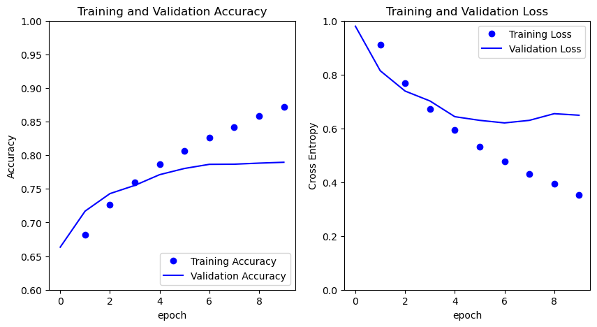

```python
acc = history.history['accuracy']
val_acc = history.history['val_accuracy']

loss = history.history['loss']
val_loss = history.history['val_loss']

fig, ((ax1, ax2)) = plt.subplots(nrows = 1,
                                 ncols = 2,
                                 figsize = (10,5))

ax1.plot(acc,'bo', label='Training Accuracy')
ax1.plot(val_acc,'b', label='Validation Accuracy')
ax1.legend(loc='lower right')
ax1.set_ylabel('Accuracy')
ax1.set_ylim(0.60, 1.00)
ax1.title.set_text('Training and Validation Accuracy')
ax1.set_xlabel('epoch')

ax2.plot(loss, 'bo', label='Training Loss')
ax2.plot(val_loss, 'b', label='Validation Loss')
ax2.legend(loc='upper right')
ax2.set_ylabel('Cross Entropy')
ax2.set_ylim(0, 1.00)
ax2.title.set_text('Training and Validation Loss')
ax2.set_xlabel('epoch')
plt.show()
```

#### Fine tuning

##### Un-freeze the top layers of the model

```python
base_model.trainable = True
```

```python
# Let's take a look to see how many layers are in the base model
print("Number of layers in the base model: ", len(base_model.layers))
```

```
Number of layers in the base model:  513
```

#### Continue training the model

```python
fine_tune_epochs = 10
total_epochs =  initial_epochs + fine_tune_epochs

history_fine = model.fit(train_ds,
                         epochs=total_epochs,
                         initial_epoch=history.epoch[-1],
                         validation_data=val_ds)
```

### Export csv file

```python
prediction = model.predict(test_ds)
test_csv = pd.read_csv("/content/public/test.csv")
export_predictions_to_csv(prediction=prediction, test_csv= test_csv, fine_grain=False)
```

## Notes on the Deep Learning Model

In this project, I have applied the transfer learning technique. This technique saves time of building a neutral network from sracth. Thanks to the pretrained model, the predictive model can achieve high accuracy from very first epochs. The dataset is split into 80% for train set and 20% for validation set.

Firstly, I freeze all of the base model's layers and then train the model, the weights of the pre-trained network were not updated during training. After that, in the fine-tuning step, I unfreeze base model's layers to adapt these specialized features to work with the new dataset, rather than overwrite the generic learning.

There are several reasons for me to choose **MobileNetV2** and **EfficientNetV2S**. In comparison of two models which are built on top of **MobileNetV2** and **EfficientNetV2S**. The model with **EfficientNetV2S** perform better when it achieve more than 80% accuracy. Meanwhile, model which is built on top of **MobileNetV2** seem to get the peak at 50% accuracy.

When talking about model architecture , I have tried both Flatten() and GlobalAveragePooling2D() layer in the model. The result is that using **Flatten()** allowed the model to capture more detailed features that contributed to better performance in the multiple class image classification task.

Regard of last Dense() layer, Dense layers with parameter 2048, 1024, 512 have been test. The size of the last dense layer is an important hyperparameter that can significantly impact the model's performance. It seem to be that **Dense(512)** provide the best performance for the model. A larger number of units allows the layer to learn more complex and expressive representations, but it also increases the model's complexity and may lead to overfitting.

About the predtion layer, activation function 'softmax' and 'sigmoid' have been tried. **Activation function 'softmax'** is likely to perform better for multiple class image classification.

### Why use MobileNetV2?

MobileNetV2 is trained using a large images dataset. It enables the model to effectively learn, therefore, we can expect accurate results.

MobileNetV2 is lightweight making it have high execution speed.

MobileNetV2 is smaller in size as compared to MobileNetV1, making it more suitable for embedded systems and mobile devices.

MobileNetV2 significantly reduces the number of parameters thus making it less complex.

MobilenetV2 can also run on web browsers since the model is lightweight as compared to MobilenetV1. Also, browsers have lower computation power, graphic processing, and storage.

### Why use EfficientNetV2S?

EfficientNetV2S has achieved state-of-the-art performance on various benchmark datasets, including ImageNet, which demonstrates its effectiveness in image classification tasks.

EfficientNet models are designed to achieve high accuracy while maintaining efficiency in terms of model size and computational requirements.

### Problems when trainning the model :

**Overfitting** : When I first tried MobileNetV2 model, after creating and freezing base model, the architecture of model was only base model layer and output layer for prediction. The result was that there is a big gap between trainning and validation accuracy. The trainning accuracy continously increased until 80% , but the val_acc reach the peak at 52% at 3rd epoch. To handle this issue, Dropout layer with dropout rate at 0.2 and L2 kernel_regularizer are added to model to reduce the overfitting problem.

[figure not shown]

#### Figure 2. The big gap between train_accuracy and val_accuracy

[figure not shown]

#### Figure 3. The gap between train_accuracy and val_accuracy becomes smaller

**Learning rate divergency** : According to the figure below, from epoch 5, the trainning loss and validation loss value become diverse significantly. At the beginning, I tried learning rate at 0.001, the situation did not improve. Therefore, I adjusted it to 0.0001 and applied L2 regularization layer to address the issue. Then, the model has been improved considerably.

[figure not shown]

#### Figure 4 . Learning rate divergency problem with the deep learning model

# Discussion of Model Performance and Implementation

The performance comparison between the final conventional ML and deep learning models reveals that the deep learning model outperformed the conventional ML model by a significant margin. The deep learning model achieved an accuracy of 83% on the public test set, surpassing the conventional ML model by 36%. This indicates that the deep learning model was able to capture more complex patterns and representations in the data, leading to improved classification accuracy.

When inspecting the data, it is crucial to analyze the characteristics and quality of the dataset. Understanding the dataset can provide insights into the challenges faced during modeling and help identify areas for improvement. Factors such as class imbalance, data distribution, and potential biases need to be carefully examined to ensure fair and unbiased model performance

In terms of resource requirements, deep learning models often demand more computational resources compared to conventional ML models. Deep learning models typically require powerful GPUs and longer training times due to their complex architectures and the need to process large amounts of data. On the other hand, conventional ML models are generally more lightweight and computationally efficient. Consideration of available resources and infrastructure is essential when deciding between deep learning and conventional ML approaches.

The deep learning model I have build perform well with image classification task for coarse-grained data which has 8 classes when model reach 80% accuracy. But with the fine-grained data which has 50 classes, deep learning model with same architecture only reach 48% accuracy.The difference in performance between the coarse-grained data (8 classes) and fine-grained data (50 classes) can be attributed to several factors: class imbalance, limited training data, complexity of distinguishing classes . The complexity of the fine-grained classification task may require a more sophisticated and higher-capacity model to capture the subtle differences.

Overall, the implementation of deep learning models for image classification tasks provides promising results, showcasing the capability of neural networks to learn intricate patterns and achieve high accuracy. However, addressing overfitting and ensuring model generalization are important considerations for future improvements. Additionally, optimizing computational resources and adapting models to specific dataset characteristics can further enhance the performance and efficiency of the models.